# Ken Der: Homework 2

December 01, 2020

## Assignment 2: Stanford Future Bay Initiative

Prepare a report analyzing education outcomes in one County (of your choice) in the Bay Area. You are welcome to include as many data-driven insights as you’d like, with the many kinds of education datasets available from the Census Bureau and elsewhere, but at the minimum, you must include:

1. An equity analysis of educational attainment by race. Plot the “stacked” and “filled” bar charts as demonstrated in 2.2; from there, you are welcome to add as many comments and supplementary visualizations as you’d like. Essentially, respond to the question: “Is there disproportionate education attainment by race in the County?” Note that the universe of the ACS datasets on educational attainment is “population 25 years or older”, so be sure to clarify that in your visuals and commentary.
2. An estimate of the number and percentage of K-12 students who have no internet access at home, using the latest available PUMS data. (Note that 2019 1-yr PUMS data will be available in mid-October 2020, so you might choose to update your analysis using that data at that time.) State your assumptions clearly, especially how useful the available data is for understanding the challenges of remote learning in 2020. Include a map of this metric for all PUMAs in the Bay Area.
3. A migration analysis, as demonstrated in 2.3, using data on educational attainment. Discuss what you believe can be interpreted from the results of this methodology, especially as it relates to the “educational mobility” of Bay Area residents.

## Setting Up

The following libraries and packages are used in this analysis:

```r
library(tidyverse)
library(ggplot2)
library(leaflet)
library(tigris)
library(sf)
library(censusapi)
library(leaflet)
library(plotly)
library(knitr)
library(dplyr)
library(lubridate)
library(tidycensus)
```

```r
acs_vars_2019_1yr <- readRDS("acs_vars_2019_1yr.rds")
```

## Part 1: Equity Analysis of Educational Attainment by Race in Alameda County

First, I’ll pull educational attainment data from the American Communities Survey (ACS), highlighted by the B15002 series of datasets from the 2019 ACS 1-Year Estimates–“SEX BY EDUCATIONAL ATTAINMENT FOR THE POPULATION 25 YEARS AND OVER”:

```r
census_race_labels <-
  c(
    "White Alone",
    "Black or African American",
    "American Indian and Alaska Native Alone",
    "Asian Alone",
    "Native Hawaiian and Other Pacific Islander Alone)",
    "Some Other Race Alone",
    "Two or More Races"
  )

alameda_ed_race <-
  1:7 %>%
  map_dfr(function(x){
    getCensus(
      name = "acs/acs1",
      vintage = 2019,
      region = "county:001",
      regionin = "state:06",
      vars = paste0("group(B15002", LETTERS[x],")")
    ) %>%
      select(!c(GEO_ID,state,NAME) & !ends_with(c("EA", "MA", "M"))) %>%
      pivot_longer(
        ends_with("E"),
        names_to = "variable",
        values_to = "estimate"
      ) %>%
      left_join(
        acs_vars_2019_1yr %>%
          select(name, label),
        by = c("variable" = "name")
      ) %>%
      select(-variable) %>%
      separate(
        label,
        into = c(NA,NA,"race", "ed_attain"),
        sep = "!!"
      ) %>%
      filter(!is.na(ed_attain))%>%
      mutate(race = census_race_labels[x])
  })
```

The data from above represented visually in stacked and filled plots, organized by race and educational attainment:

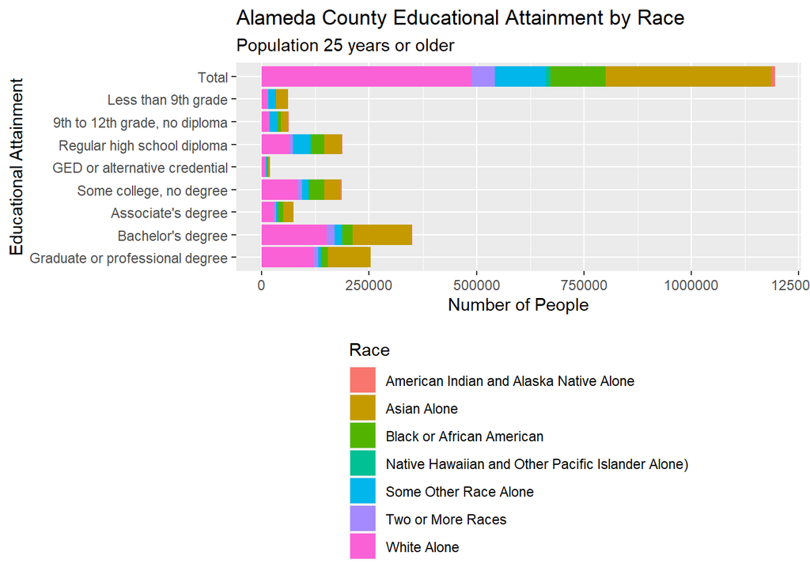

```r
alameda_ed_race_total <-
  alameda_ed_race %>%
  group_by(race) %>%
  summarize(estimate = sum(estimate)) %>%
  mutate(ed_attain = "Total")

alameda_ed_race_plot_stack <-alameda_ed_race %>%
  group_by(ed_attain, race) %>%
  summarize(estimate = sum(estimate)) %>%
  rbind.data.frame(alameda_ed_race_total) %>%
  ggplot() +
  geom_bar(
    aes(
      x = ed_attain %>% factor(levels = rev(c("Total", alameda_ed_race$ed_attain[1:8]))),
      y = estimate,
      fill = race
    ),
    stat = "identity",
    position = "stack"
  ) +
  labs(
    x = "Educational Attainment",
    y = "Number of People",
    title = "Alameda County Educational Attainment by Race",
    subtitle = "Population 25 years or older",
    fill = "Race"
  ) +
  coord_flip() +
  theme(
    legend.position = "bottom",
    legend.direction = "vertical"
  )

alameda_ed_race_plot_fill <-alameda_ed_race %>%
  group_by(ed_attain, race) %>%
  summarize(estimate = sum(estimate)) %>%
  rbind.data.frame(alameda_ed_race_total) %>%
  ggplot() +
  geom_bar(
    aes(
      x = ed_attain %>% factor(levels = rev(c("Total", alameda_ed_race$ed_attain[1:8]))),
      y = estimate,
      fill = race
    ),
    stat = "identity",
    position = "fill"
  ) +
  labs(
    x = "Educational Attainment",
    y = "Percentage",
    title = "Alameda County Educational Attainment by Race",
    subtitle = "Population 25 years or older",
    fill = "Race"
  ) +
  coord_flip() +
  theme(
    legend.position = "bottom",
    legend.direction = "vertical"
  )

alameda_race_ed_plot_fill <-alameda_ed_race %>%
  group_by(ed_attain, race) %>%
  summarize(estimate = sum(estimate)) %>%
  ggplot() +
  geom_bar(
    aes(
      x = race,
      y = estimate,
      fill = ed_attain %>% factor(levels = rev(c("Total", alameda_ed_race$ed_attain[1:8])))
    ),
    stat = "identity",
    position = "fill"
  ) +
  labs(
    x = "Race",
    y = "Percentage",
    title = "Alameda County Educational Attainment by Race",
    subtitle = "Population 25 years or older",
    fill = "Race"
  ) +
  coord_flip() +
  theme(
    legend.position = "bottom",
    legend.direction = "vertical"
  )

alameda_ed_race_plot_stack
```

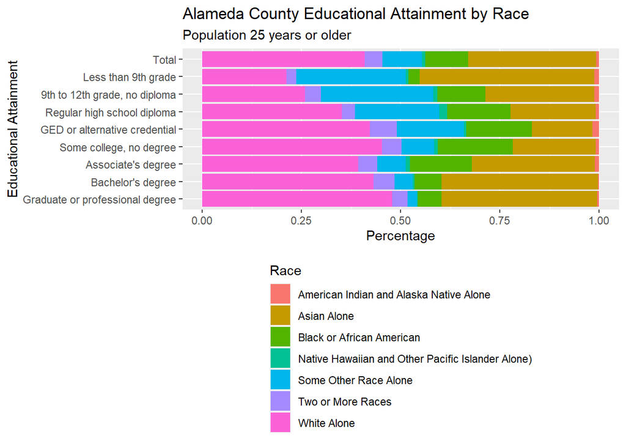

```r
alameda_ed_race_plot_fill
```

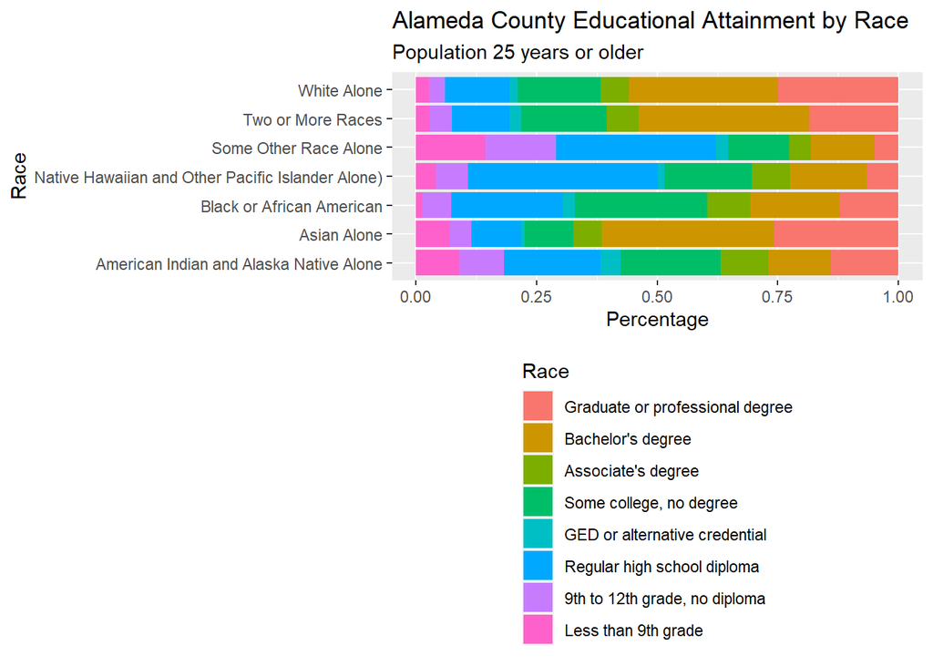

```r
alameda_race_ed_plot_fill
```

```r
paste0("The overall population of Alameda County residents 25 years or older is ", ((sum(alameda_ed_race_total$estimate[3])/sum(alameda_ed_race_total$estimate))*100) %>% round(1), "% Black or African-American. However, ", ((alameda_ed_race %>%
  filter(ed_attain %in% alameda_ed_race$ed_attain[1:4]) %>%
  filter(race == "Black or African American") %>%
  pull(estimate) %>%
  sum()) /
  (alameda_ed_race %>%
    filter(ed_attain %in% alameda_ed_race$ed_attain[1:4]) %>%
    pull(estimate) %>%
    sum()) * 100) %>%
  round(1), "% of the population who have not attended college or have a college degree are Black or African-American. Should there not exist educational attainment gaps by race, these percentages should be the same. Black or African-American populations are ", ((((alameda_ed_race %>%
  filter(ed_attain %in% alameda_ed_race$ed_attain[1:4]) %>%
  filter(race == "Black or African American") %>%
  pull(estimate) %>%
  sum()) /
  (alameda_ed_race %>%
    filter(ed_attain %in% alameda_ed_race$ed_attain[1:4]) %>%
    pull(estimate) %>%
    sum())) / (sum(alameda_ed_race_total$estimate[3])/sum(alameda_ed_race_total$estimate)) - 1) * 100) %>%
  round(1), "% more likely to not attend college or hold a college degree.")
```

```
## [1] "The overall population of Alameda County residents 25 years or older is 10.7% Black or African-American. However, 12.8% of the population who have not attended college or have a college degree are Black or African-American. Should there not exist educational attainment gaps by race, these pe…
```

```r
paste0("The overall population of Alameda County residents 25 years or older is ", ((sum(alameda_ed_race_total$estimate[5])/sum(alameda_ed_race_total$estimate))*100) %>% round(1), "% Some Other Race Alone. However, ", ((alameda_ed_race %>%
  filter(ed_attain %in% alameda_ed_race$ed_attain[1:4]) %>%
  filter(race == "Some Other Race Alone") %>%
  pull(estimate) %>%
  sum()) /
  (alameda_ed_race %>%
    filter(ed_attain %in% alameda_ed_race$ed_attain[1:4]) %>%
    pull(estimate) %>%
    sum()) * 100) %>%
  round(1), "% of the population who have not attended college or have a college degree are Some Other Race Alone. Some Other Race Alone populations are ", ((((alameda_ed_race %>%
  filter(ed_attain %in% alameda_ed_race$ed_attain[1:4]) %>%
  filter(race == "Some Other Race Alone") %>%
  pull(estimate) %>%
  sum()) /
  (alameda_ed_race %>%
    filter(ed_attain %in% alameda_ed_race$ed_attain[1:4]) %>%
    pull(estimate) %>%
    sum())) / (sum(alameda_ed_race_total$estimate[5])/sum(alameda_ed_race_total$estimate)) - 1) * 100) %>%
  round(1), "% more likely to not attend college or hold a college degree.")
```

```
## [1] "The overall population of Alameda County residents 25 years or older is 10% Some Other Race Alone. However, 23.5% of the population who have not attended college or have a college degree are Some Other Race Alone. Some Other Race Alone populations are 134.2% more likely to not attend college…
```

```r
paste0("The overall population of Alameda County residents 25 years or older is ", ((sum(alameda_ed_race_total$estimate[2])/sum(alameda_ed_race_total$estimate))*100) %>% round(1), "% Asian Alone. However, ", ((alameda_ed_race %>%
  filter(ed_attain %in% alameda_ed_race$ed_attain[1:4]) %>%
  filter(race == "Asian Alone") %>%
  pull(estimate) %>%
  sum()) /
  (alameda_ed_race %>%
    filter(ed_attain %in% alameda_ed_race$ed_attain[1:4]) %>%
    pull(estimate) %>%
    sum()) * 100) %>%
  round(1), "% of the population who have not attended college or have a college degree are Asian Alone. Asian Alone populations are ", ((((alameda_ed_race %>%
  filter(ed_attain %in% alameda_ed_race$ed_attain[1:4]) %>%
  filter(race == "Asian Alone") %>%
  pull(estimate) %>%
  sum()) /
  (alameda_ed_race %>%
    filter(ed_attain %in% alameda_ed_race$ed_attain[1:4]) %>%
    pull(estimate) %>%
    sum())) / (sum(alameda_ed_race_total$estimate[2])/sum(alameda_ed_race_total$estimate)) - 1) * 100) %>%
  round(1), "% more likely to not attend college or hold a college degree. In other words, Asian Alone populations are 18.3% more likely to attend college or hold a college degree.")
```

```
## [1] "The overall population of Alameda County residents 25 years or older is 32.4% Asian Alone. However, 26.5% of the population who have not attended college or have a college degree are Asian Alone. Asian Alone populations are -18.3% more likely to not attend college or hold a college degree. I…
```

```r
paste0("The overall population of Alameda County residents 25 years or older is ", ((sum(alameda_ed_race_total$estimate[7])/sum(alameda_ed_race_total$estimate))*100) %>% round(1), "% White Alone. However, ", ((alameda_ed_race %>%
  filter(ed_attain %in% alameda_ed_race$ed_attain[1:4]) %>%
  filter(race == "White Alone") %>%
  pull(estimate) %>%
  sum()) /
  (alameda_ed_race %>%
    filter(ed_attain %in% alameda_ed_race$ed_attain[1:4]) %>%
    pull(estimate) %>%
    sum()) * 100) %>%
  round(1), "% of the population who have not attended college or have a college degree are White Alone. White Alone populations are ", ((((alameda_ed_race %>%
  filter(ed_attain %in% alameda_ed_race$ed_attain[1:4]) %>%
  filter(race == "White Alone") %>%
  pull(estimate) %>%
  sum()) /
  (alameda_ed_race %>%
    filter(ed_attain %in% alameda_ed_race$ed_attain[1:4]) %>%
    pull(estimate) %>%
    sum())) / (sum(alameda_ed_race_total$estimate[7])/sum(alameda_ed_race_total$estimate)) - 1) * 100) %>%
  round(1), "% more likely to not attend college or hold a college degree. In other words, White Alone populations are 23.7% more likely to attend college or hold a college degree")
```

```
## [1] "The overall population of Alameda County residents 25 years or older is 41% White Alone. However, 31.2% of the population who have not attended college or have a college degree are White Alone. White Alone populations are -23.7% more likely to not attend college or hold a college degree. In …
```

**These disparities between actual population and college enrollment indeed highlight that there is an educational attainment gap by race in Alameda County.**

## Part 2: Number and Percentage of K-12 Students Without Home Internet Access in Alameda County

In this analysis, I uses the 1-Year Public Use Microdata Sample (PUMS) data from 2019.

```r
pums_vars_2019 <-
  pums_variables %>%
  filter(year == 2019, survey == "acs1")

pums_vars_2019_distinct <-
  pums_vars_2019 %>%
  distinct(var_code, var_label, data_type, level)
```

I pull Public Use Microdata Areas (PUMAs), school grade level attending (SCHG), and access to the internet (ACCESS) variables, and save them into an RDS. Further explanations of the variable codes can be found at: https://www2.census.gov/programs-surveys/acs/tech_docs/pums/data_dict/PUMSDataDict13.txt

```r
ca_pums_internet <- readRDS("ca_pums_internet.rds")
```

Here, I select Alameda County as the geographical point of analysis, and manipulate the data to identify the percentage and number of K-12 students who lack internet access at home for any given PUMA in Alameda County. The map highlighting percentages is drawn below:

```r
alameda_county <-
  counties("CA", cb = T, progress_bar = F) %>%
  filter(NAME == "Alameda")

ca_pumas <-
  pumas("CA", cb = T, progress_bar = F)

alameda_pumas <-
  ca_pumas %>%
  st_centroid() %>%
  .[alameda_county, ] %>%
  st_set_geometry(NULL) %>%
  left_join(ca_pumas %>% select(GEOID10)) %>%
  st_as_sf()

alameda_pums <-
  ca_pums_internet %>%
  filter(PUMA %in% alameda_pumas$PUMACE10)

alameda_pums_internet <-
  alameda_pums %>%
  filter(!duplicated(SERIALNO)) %>%
  mutate(
    total_gradesch = ifelse(
        (SCHG_label != c("N/A (not attending school)", "Nursery school/preschool","College undergraduate years (freshman to senior)","Graduate or professional school beyond a bachelor's degree")),
      PWGTP,
      0
    )
  ) %>%
  mutate(
    nonaccess_gradesch = ifelse(
      (ACCESS_label == "No access to the Internet at this house, apartment, or mobile home") &
        (SCHG_label != c("N/A (not attending school)", "Nursery school/preschool","College undergraduate years (freshman to senior)","Graduate or professional school beyond a bachelor's degree")),
      PWGTP,
      0
    )
  ) %>%
  group_by(PUMA) %>%
  summarize(
    K12_Students_Without_Home_Internet = sum(nonaccess_gradesch),
    Total_K12_Students = sum(total_gradesch),
    PCT_K12_Students_Without_Home_Internet =
      sum(nonaccess_gradesch, na.rm =T)/sum(total_gradesch, na.rm = T)*100
  ) %>%
  left_join(
    alameda_pumas %>%
      select(PUMACE10),
    by = c("PUMA" = "PUMACE10")
  ) %>%
  st_as_sf()

pums_pal <- colorNumeric(
  palette = "plasma",
  domain = alameda_pums_internet$PCT_K12_Students_Without_Home_Internet
)

leaflet() %>%
  addTiles() %>%
  addPolygons(
    data = alameda_pums_internet,
    fillColor = ~pums_pal(PCT_K12_Students_Without_Home_Internet),
    color = "black",
    opacity = 0.5,
    fillOpacity = 0.5,
    weight = 2,
    label = ~paste0(
      round(PCT_K12_Students_Without_Home_Internet),
      "% of K-12 students without home internet access"
    ),
    highlightOptions = highlightOptions(
      weight = 4,
      opacity = 1
    )
  ) %>%
  addLegend(
    data = alameda_pums_internet,
    pal = pums_pal,
    values = ~PCT_K12_Students_Without_Home_Internet,
    title = "% of K-12 Students in Alameda County<br>Without Home Internet Access"
  )
```

[interactive chart not shown]

```r
sum(alameda_pums_internet$K12_Students_Without_Home_Internet)
```

```
## [1] 33444
```

```r
sum(alameda_pums_internet$Total_K12_Students)
```

```
## [1] 465839
```

From this analysis, **I estimate that about 33,444 students in Alameda County lack home internet access, out of 465,839 total K-12 students. This represents an average of 7.2% of students who lack home internet access in Alameda County.** To make this conclusion, I assumed a Yes/No binary for internet access in the home as provided by the ACS data, when, in reality, the truth could potentially be more complicated (e.g. spotty or unreliable internet access). Also, this analysis takes into account all K-12 students instead of children 5-18 to capture grade level as opposed to children’s internet access in general.

This data is useful to help identify areas within a county where additional attention or support is warranted to ensure that all students have access to home internet during the pandemic. Indeed, the analysis found that 18% of East Oakland students did not have home internet access, which is critical for remote learning during the pandemic. Further study should tackle whether such students are within walking distance of a library or other community hub that can provide internet and other technology.

## Part 3: Migration Analysis, Based on Educational Attainment

In this final portion, I perform a migration analysis for Alameda County based on educational attainment. First, I pull mobility data, represented by the B7009 series of datasets from the 2018 and 2019 ACS 1-Year Estimates–“GEOGRAPHICAL MOBILITY IN THE PAST YEAR BY EDUCATIONAL ATTAINMENT FOR CURRENT RESIDENCE IN THE UNITED STATES”, as well as the B7409 series from the 2019 ACS 1-Year Estimates–“GEOGRAPHICAL MOBILITY IN THE PAST YEAR BY EDUCATIONAL ATTAINMENT FOR RESIDENCE 1 YEAR AGO IN THE UNITED STATES”. These datasets help provide context for movement in the year 2019 by also including conditions for the previous year.

```r
ala_co_mobility_current_19 <-
  getCensus(
    name = "acs/acs1",
    vintage = 2019,
    region = "county:001",
    regionin = "state:06",
    vars = c("group(B07009)")
  ) %>%
  select(!c(GEO_ID,state,NAME) & !ends_with(c("EA","MA","M"))) %>%
  pivot_longer(
    ends_with("E"),
    names_to = "variable",
    values_to = "estimate"
  ) %>%
  left_join(
    acs_vars_2019_1yr %>%
      select(name, label),
    by = c("variable" = "name")
  ) %>%
  select(-variable) %>%
  separate(
    label,
    into = c(NA,NA,"mobility","ed_attain"),
    sep = "!!"
  ) %>%
  mutate(
    mobility = ifelse(
      mobility %in% c("Same house 1 year ago:", "Moved within same county:"),
      "Here since last year",
      "Inflow"
    )
  ) %>%
  filter(!is.na(ed_attain)) %>%
  group_by(mobility, ed_attain) %>%
  summarize(estimate = sum(estimate))

ala_co_mobility_lastyear_19 <-
  getCensus(
    name = "acs/acs1",
    vintage = 2019,
    region = "county:001",
    regionin = "state:06",
    vars = c("group(B07409)")
  ) %>%
  select(!c(GEO_ID,state,NAME) & !ends_with(c("EA","MA","M"))) %>%
  pivot_longer(
    ends_with("E"),
    names_to = "variable",
    values_to = "estimate"
  ) %>%
  left_join(
    acs_vars_2019_1yr %>%
      select(name, label),
    by = c("variable" = "name")
  ) %>%
  select(-variable) %>%
  separate(
    label,
    into = c(NA,NA,"mobility","ed_attain"),
    sep = "!!"
  ) %>%
  mutate(
    mobility = ifelse(
      mobility %in% c("Same house:", "Moved within same county:"),
      "Here since last year",
      "Outflow"
    )
  ) %>%
  filter(!is.na(ed_attain)) %>%
  group_by(mobility, ed_attain) %>%
  summarize(estimate = sum(estimate))

ala_co_mobility_current_18 <-
  getCensus(
    name = "acs/acs1",
    vintage = 2018,
    region = "county:001",
    regionin = "state:06",
    vars = c("group(B07009)")
  ) %>%
  select(!c(GEO_ID,state,NAME) & !ends_with(c("EA","MA","M"))) %>%
  pivot_longer(
    ends_with("E"),
    names_to = "variable",
    values_to = "estimate"
  ) %>%
  left_join(
    acs_vars_2019_1yr %>%
      select(name, label),
    by = c("variable" = "name")
  ) %>%
  select(-variable) %>%
  separate(
    label,
    into = c(NA,NA,"mobility","ed_attain"),
    sep = "!!"
  ) %>%
  mutate(
    mobility = "Here last year"
  ) %>%
  filter(!is.na(ed_attain)) %>%
  group_by(mobility, ed_attain) %>%
  summarize(estimate = sum(estimate))
```

Finally, I bind these pulled datasets together:

```r
ala_co_flows_19 <-
  rbind.data.frame(
    ala_co_mobility_current_18,
    ala_co_mobility_lastyear_19 %>%
      filter(mobility == "Outflow"),
    ala_co_mobility_current_19 %>%
      filter(mobility == "Inflow"),
    ala_co_mobility_current_19 %>%
      group_by(ed_attain) %>%
      summarize(estimate = sum(estimate)) %>%
      mutate(mobility = "Here this year")
  ) %>%
  pivot_wider(
    names_from = mobility,
    values_from = estimate
  ) %>%
  mutate(
    `External net` = Inflow - Outflow,
    `Internal net` = `Here this year` - `Here last year` - `External net`,
  ) %>%
  select(
    `Education Attainment` = ed_attain,
    `Internal net`,
    `External net`,
    `Here last year`,
    `Here this year`,
    Outflow,
    Inflow
  )

x <- c("Less than high school graduate", "High school graduate (includes equivalency)", "Some college or associate's degree", "Bachelor's degree", "Graduate or professional degree")

ala_co_flows_19 %>% slice(match(x, `Education Attainment`))
```

```
## # A tibble: 5 x 7
##   `Education Atta~ `Internal net` `External net` `Here last year`
##   <chr>                     <dbl>          <dbl>            <dbl>
## 1 Less than high ~          -1335           1174           124223
## 2 High school gra~          -7992            -15           214368
## 3 Some college or~          -8890          -6028           274788
## 4 Bachelor's degr~          18271           6034           326386
## 5 Graduate or pro~           6148           1515           246460
## # ... with 3 more variables: `Here this year` <dbl>, Outflow <dbl>,
## #   Inflow <dbl>
```